# Final Project - Introduction to Quantitative Analysis

Author

Esiquio Iglesias Guerra

Published

Invalid Date

## From Data to Decisions: Understanding the Housing Prices determinants.

### Research Question

What is the influence of variables such as house features (# of bed, #of bathroom, house size, lot size), location (Region), median household income, density of population and crime index in determining housing prices using regression models?

This study aims to build predictive models to assess the impact of these variables on housing prices in Massachusetts, employing regression models. By analyzing the significance and magnitude of coefficients, we aim to provide insights into the factors driving housing market dynamics and inform decision-making for various stakeholders.

**Literature Review**

Previous research has consistently shown that household income is a significant determinant of housing prices. Higher household income generally correlates with the ability to afford more expensive housing. For example, studies by Haurin, Parcel, and Haurin (2002) and Muth (1969) have demonstrated a positive relationship between household income levels and housing prices. This is often explained by the fact that individuals with higher incomes can afford larger loans and they are comfortable with pay more for best neighborhoods and amenities.

The relationship between crime rates and housing prices is complex but well-studied. Research by Cullen and Levitt (1999) and Bajari, Benkard, and Krainer (2005) has shown that higher crime rates tend are related with a decrease housing prices in affected areas. This can be attributed to various factors, including perceptions of safety, the cost of security equipment, and insurance’s cost. For instance, areas with high crime rates may experience a decrease in property values.

Population density also plays a crucial role in housing prices. Research by Gyourko, Mayer, and Sinai (2006) and Saiz (2010) has highlighted the relationship between population density and housing prices. High population density areas often have a greater demand for housing, leading to higher prices. For example, areas with high population density may have more facilities for examples, universities, shopping malls, hospital, recreation facilities, and more.

**-Motivation:**

The housing market is a complex and dynamic system influenced by various factors, including property features, regional differences, economic conditions and demographics characteristics. Understanding the drivers of housing prices is crucial for homeowners, real estate professionals, policymakers, and investors alike. By evaluating the influence of key variables such as the number of bedrooms, number of bathrooms, lot size, house size, and location (state), we can gain valuable insights into the housing market dynamics and enhance decision-making processes. Finally, with advanced statistical techniques and the availability of a good datasets, there is an opportunity to develop predictive models that accurately predict housing prices.

### Hypothesis

**Hypothesis #1: Larger houses is associated with higher housing prices linked to price perception, utility, prestige and status.**

Sub-hypothesis:

- H1-1: The number of bedrooms positively correlates with higher housing prices.

- H1-2: The number of bathrooms is positively associated with increased housing prices.

- H1-3: Larger house sizes in square feet are positively linked to higher house prices.

- H1-4: Increased lot or property sizes are positively correlated with higher housing prices.

**Hypothesis #2: The location of the house and its social and economic relationships are significantly correlated with its price.**

Sub-hypothesis:

- H2-1: Housing prices are higher in Western MA due to factors such as scenic landscapes, proximity to urban centers, and potentially lower crime rates compared to more urban areas.

- H2-2: Regions with higher average household incomes will have higher housing prices because individuals with higher incomes can afford more expensive housing based in status, prestige, amenities and comfort.

- H2-3: Areas with higher population densities will experience higher housing prices because they offer locations with access to amenities, employment opportunities, cultural attractions, and more.

- H3-3: Areas with higher crime rates are positively correlated with lower housing prices due to perceptions of insecurity, increased insurance premiums, and the need for costly security measures.

### Descriptive Statistics

1. **Housing features and price dataset**

Data was collected from - https://www.realtor.com/ - A real estate listing website operated by the News Corp subsidiary Move, Inc. and based in Santa Clara, California. It is the second most visited real estate listing website in the United States as of 2024, with over 100 million monthly active users.

**realtor-data.csv (2,226,382 entries)**

- brokered by (categorically encoded agency/broker)
- status (Housing status - a. ready for sale or b. ready to build)
- price (Housing price, it is either the current listing price or recently sold price if the house is sold recently)
- bed (# of beds)
- bath (# of bathrooms)
- acre_lot (Property / Land size in acres)
- street (categorically encoded street address)
- city (city name)
- state (state name)
- zip_code (postal code of the area)
- house_size (house area/size/living space in square feet)
- prev_sold_date (Previously sold date)

```r
options(repos = "https://cloud.r-project.org")
install.packages("rmarkdown")
install.packages("tidyverse")
library(tidyverse)
library(ggplot2)

# Import data
us_housing_data <- read.csv("realtor-data.csv", colClasses = c(zip_code = "character"))

us_housing_data <- subset(us_housing_data, select = -c(brokered_by, prev_sold_date, street))

housing_mass <- us_housing_data[us_housing_data$state == "Massachusetts",]

head(housing_mass)
```

|  | status | price | bed | bath | acre_lot | city | state | zip_code | house_size |
| --- | --- | --- | --- | --- | --- | --- | --- | --- | --- |
| 3404 | for_sale | 180000 | 2 | 1 | 0.34 | Agawam | Massachusetts | 01001 | 676 |
| 3405 | for_sale | 25000 | NA | NA | 3.41 | Agawam | Massachusetts | 01001 | NA |
| 3406 | for_sale | 169900 | 2 | 2 | NA | Agawam | Massachusetts | 01001 | 892 |
| 3407 | for_sale | 242000 | 2 | 2 | NA | Agawam | Massachusetts | 01001 | 1428 |
| 3408 | for_sale | 299950 | 2 | 2 | NA | Agawam | Massachusetts | 01001 | 1659 |
| 3409 | for_sale | 239900 | 3 | 1 | 0.46 | Agawam | Massachusetts | 01001 | 1196 |

```r
dim(housing_mass)
```

```
[1] 38041     9
```

2. **Counties Dataset per zipcode**

This dataset include all the zip codes in the Massachusetts State, this data was collected from https://www.unitedstateszipcodes.org/ma/

**zipcodes_counties.csv (703 entries)**

- zip (zip code)
- primary_city (Primary City in the zipcode
- county (County of the zip code)

```r
counties_data <- read.csv("zipcodes_counties.csv", colClasses = c(zip_code = "character"))

head(counties_data)
```

|  | zip_code | primary_city | county |
| --- | --- | --- | --- |
| 1 | 01001 | Agawam | Hampden County |
| 2 | 01002 | Amherst | Hampshire County |
| 3 | 01003 | Amherst | Hampshire County |
| 4 | 01004 | Amherst | Hampshire County |
| 5 | 01005 | Barre | Worcester County |
| 6 | 01007 | Belchertown | Hampshire County |

```r
dim(counties_data)
```

```
[1] 703   3
```

3. **Median of Household income per zip code**

This dataset include all the zip codes in the Massachusetts State with the information about median of household income in $, based on ACS 2010-2014 data. This data was collected from: http://www.usa.com/rank/massachusetts-state--median-household-income--zip-code-rank.htm

**household_income_zipcode.csv (521 entries)**

- household_income (Value of median household income in dollars $)
- zip_code (zip code)
- population (Total of population)

```r
income_data <- read.csv("household_income_zipcode.csv", colClasses = c(zip_code = "character"))
head(income_data)
```

|  | household_income | zip_code | population |
| --- | --- | --- | --- |
| 1 | 203009 | 02468 | 5374 |
| 2 | 201200 | 02493 | 11704 |
| 3 | 184107 | 01467 | 440 |
| 4 | 177083 | 02481 | 16320 |
| 5 | 176250 | 02030 | 5727 |
| 6 | 169505 | 01776 | 18197 |

```r
dim(income_data)
```

```
[1] 521   3
```

4. **Density of population per zipcode**

This dataset include all the zip codes in the Massachusetts State with the information about density of population per square mile (sq mi). This data was collected from: http://www.usa.com/rank/massachusetts-state--population-density--zip-code-rank.htm

**density_population_zipcode.csv (535 entries)**

- population_density (density of population per square mile (sq mi))
- zip_code (zip code)

```r
denpop_data <- read.csv("density_population_zipcode.csv", colClasses = c(zip_code = "character"))
head(denpop_data)
```

|  | population_density | zip_code |
| --- | --- | --- |
| 1 | 73083.6 | 02113 |
| 2 | 39380.6 | 02115 |
| 3 | 30328.5 | 02116 |
| 4 | 29554.1 | 02108 |
| 5 | 27960.0 | 01086 |
| 6 | 27568.1 | 02215 |

```r
dim(denpop_data)
```

```
[1] 535   2
```

**Crime index per Cities**

This dataset include all the cities in the Massachusetts State with the information about crime index.The crime index value is calculated based on the data using USA.com algorithms. It is an indicator of the crime level in a region. Higher crime index value means more crime.This data was collected from: http://www.usa.com/rank/massachusetts-state--crime-index--city-rank.htm

**crime_index_city.csv (302 entries)**

- crime_index (Crime index in the city, higher crime index means more crime)
- city (Name of the City)

```r
crime_index_data <- read.csv("crime_index_city.csv")
head(crime_index_data)
```

|  | crime_index | city |
| --- | --- | --- |
| 1 | 1,074 | Abington |
| 2 | 474 | Acton |
| 3 | 728 | Acushnet |
| 4 | 1,502 | Adams |
| 5 | 666 | Agawam |
| 6 | 821 | Amesbury |

```r
dim(crime_index_data)
```

```
[1] 302   2
```

#### Putting all dataset together and build the main analysis data

This process consist in do a several joins of dataset with the goal of putt all the data and variables together in a main dataset for continue with the analysis.

```r
main_housing_data <- inner_join(housing_mass, counties_data, by = "zip_code")

main_housing_data <- inner_join(main_housing_data, income_data, by = "zip_code")

main_housing_data <- inner_join(main_housing_data, denpop_data, by = "zip_code")

main_housing_data <- inner_join(main_housing_data, crime_index_data, by = "city")

dim(main_housing_data)
```

```
[1] 33071    15
```

```r
head(main_housing_data)
```

|  | status | price | bed | bath | acre_lot | city | state | zip_code | house_size | primary_city | county | household_income | population | population_density | crime_index |
| --- | --- | --- | --- | --- | --- | --- | --- | --- | --- | --- | --- | --- | --- | --- | --- |
| 1 | for_sale | 180000 | 2 | 1 | 0.34 | Agawam | Massachusetts | 01001 | 676 | Agawam | Hampden County | 60775 | 17141 | 1393.2 | 666 |
| 2 | for_sale | 25000 | NA | NA | 3.41 | Agawam | Massachusetts | 01001 | NA | Agawam | Hampden County | 60775 | 17141 | 1393.2 | 666 |
| 3 | for_sale | 169900 | 2 | 2 | NA | Agawam | Massachusetts | 01001 | 892 | Agawam | Hampden County | 60775 | 17141 | 1393.2 | 666 |
| 4 | for_sale | 242000 | 2 | 2 | NA | Agawam | Massachusetts | 01001 | 1428 | Agawam | Hampden County | 60775 | 17141 | 1393.2 | 666 |
| 5 | for_sale | 299950 | 2 | 2 | NA | Agawam | Massachusetts | 01001 | 1659 | Agawam | Hampden County | 60775 | 17141 | 1393.2 | 666 |
| 6 | for_sale | 239900 | 3 | 1 | 0.46 | Agawam | Massachusetts | 01001 | 1196 | Agawam | Hampden County | 60775 | 17141 | 1393.2 | 666 |

#### Removing NA’s values

This process is for remove all the NA values in the dataset

```r
na_counts <- colSums(is.na(main_housing_data))
main_housing_data <- na.omit(main_housing_data)
na_counts
```

```
            status              price                bed               bath
                 0                  0               1866               1795
          acre_lot               city              state           zip_code
              6976                  0                  0                  0
        house_size       primary_city             county   household_income
              1763                  0                  0                  0
        population population_density        crime_index
                 0                  0                  0
```

```r
dim(main_housing_data)
```

```
[1] 24283    15
```

#### Selection of the variables for the analysis

In this project I’ll be focused in variables related with house features, population, localization, economics and crime.

Dependent variable (DV)

- price (house price)

```r
summary(main_housing_data$price)
```

```
    Min.  1st Qu.   Median     Mean  3rd Qu.     Max.
   10000   379900   549000   757819   798000 30000000
```

Independent variables (IV):

1. bed (number of bedrooms in the house)

```r
summary(main_housing_data$bed)
```

```
   Min. 1st Qu.  Median    Mean 3rd Qu.    Max.
   1.00    3.00    3.00    3.75    4.00   99.00
```

2. bath (number of bathrooms in the house)

```r
summary(main_housing_data$bath)
```

```
   Min. 1st Qu.  Median    Mean 3rd Qu.    Max.
  1.000   2.000   2.000   2.498   3.000 198.000
```

3. acre_lot (Property / Land size in acres)

```r
summary(main_housing_data$acre_lot)
```

```
   Min. 1st Qu.  Median    Mean 3rd Qu.    Max.
   0.00    0.14    0.27    2.11    0.63 2295.68
```

4. Region (Region of Massachusetts) using the following distribution:
- Western Massachusetts: Berkshire County, Franklin County, Hampton County, Hamden County.
- Central Massachusetts: Worcester County
- Northeast Massachusetts: Essex County, Middlesex County, Suffolk County
- Southeast Massachusetts: Norfolk County, Bristol County, Plymouth County, Barnstable County, Dukes County, Nantucket County

```r
main_housing_data <- main_housing_data %>%
  mutate(region = case_when(
    county %in% c('Berkshire County', 'Franklin County', 'Hampshire County', 'Hampden County') ~ "Western",
    county %in% c('Worcester County') ~ "Central",
    county %in% c('Essex County', 'Middlesex County', 'Suffolk County') ~ "Northeast",
    county %in% c('Norfolk County', 'Bristol County', 'Plymouth County', 'Barnstable County', 'Dukes County', 'Nantucket County') ~ "Southeast"))

summary_region <- main_housing_data %>%
  group_by(region) %>%
  summarise(count = n())
summary_region
```

| region | count |
| --- | --- |
| Central | 3709 |
| Northeast | 9596 |
| Southeast | 7253 |
| Western | 3725 |

5. house_size (Size of the house in square feet)

```r
summary(main_housing_data$house_size)
```

```
   Min. 1st Qu.  Median    Mean 3rd Qu.    Max.
    170    1365    1875    2202    2640   72000
```

6. household_income (Value of median household income in dollars $)

```r
summary(main_housing_data$household_income)
```

```
   Min. 1st Qu.  Median    Mean 3rd Qu.    Max.
  17657   56000   72472   75913   88794  203009
```

7. population_density (density of population per square mile (sq mi))

```r
summary(main_housing_data$population_density)
```

```
   Min. 1st Qu.  Median    Mean 3rd Qu.    Max.
   19.5   640.2  1437.0  3515.9  4030.6 73083.6
```

8. crime_index (Crime index in the city, higher crime index means more crime)

```r
main_housing_data$crime_index <- gsub(',', '', main_housing_data$crime_index)
main_housing_data$crime_index <- as.numeric(main_housing_data$crime_index)
summary(main_housing_data$crime_index)
```

```
   Min. 1st Qu.  Median    Mean 3rd Qu.    Max.
  154.0   601.5   955.0  1264.8  1820.0  3621.0
```

### Visualization

#### Number of Bedrooms

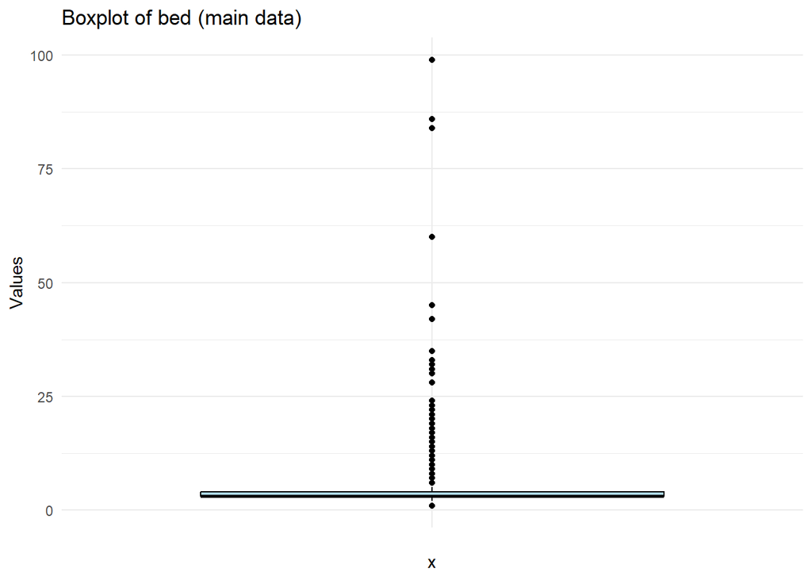

```r
ggplot(main_housing_data, aes(x = "", y = bed)) +
  geom_boxplot(fill = "lightblue", color = "black") +
  labs(title = "Boxplot of bed (main data)", y = "Values") +
  theme_minimal()
```

**Interpretation:** This boxplot show that the variable bed have a lot of outliers, so next step is proceed to remove the outliers, creating a function and use the quantiles a IQR.

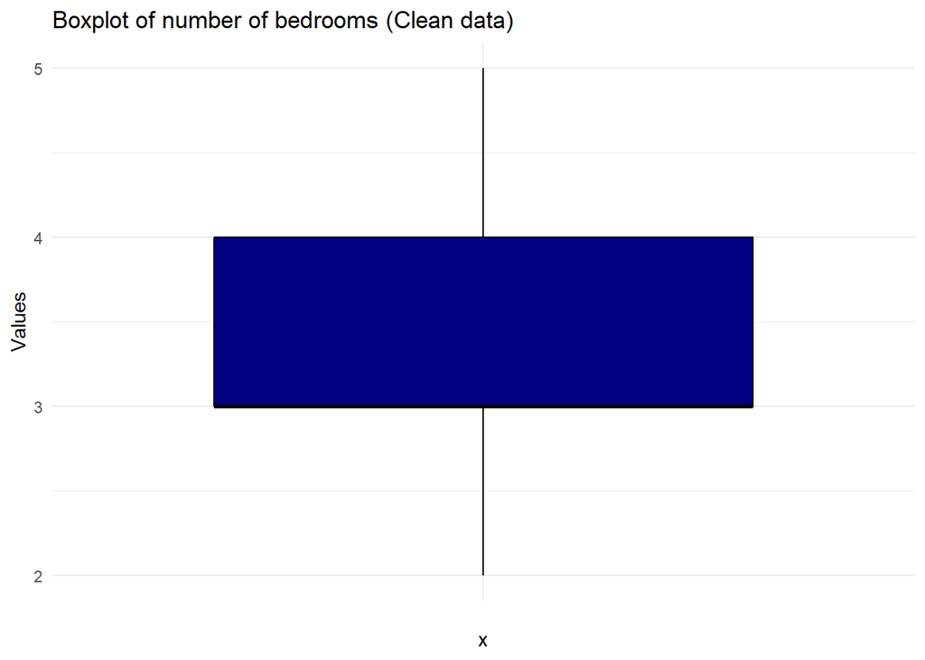

```r
remove_outliers <- function(data, column_name) {
  Q1 <- quantile(data[[column_name]], 0.25)
  Q3 <- quantile(data[[column_name]], 0.75)
  IQR <- Q3 - Q1
  lower_bound <- Q1 - 1.5 * IQR
  upper_bound <- Q3 + 1.5 * IQR
  data <- data[data[[column_name]] >= lower_bound & data[[column_name]] <= upper_bound, ]
  return(data)
}

clean_housing_data <- remove_outliers(main_housing_data, "bed")

ggplot(clean_housing_data, aes(x = "", y = bed)) +
  geom_boxplot(fill = "navyblue", color = "black") +
  labs(title = "Boxplot of number of bedrooms (Clean data)", y = "Values") +
  theme_minimal()
```

```r
dim(clean_housing_data)
```

```
[1] 21297    16
```

**Interpretation**: This new boxplot for the variable bed, shows a better distribution for the numbers of bedrooms in the dataset.

#### Number of Bathrooms

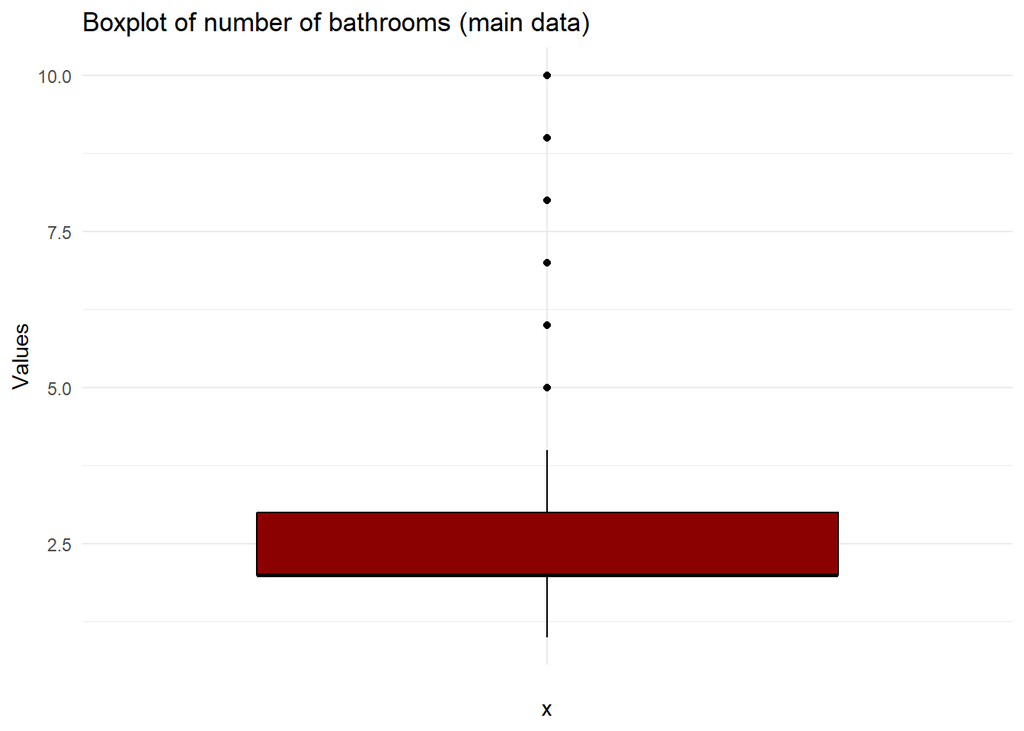

```r
ggplot(clean_housing_data, aes(x = "", y = bath)) +
  geom_boxplot(fill = "darkred", color = "black") +
  labs(title = "Boxplot of number of bathrooms (main data)", y = "Values") +
  theme_minimal()
```

**Interpreation:** This box plot for the variable bath shows some outliers out of the box, so proceed to remove the outliers using the function before created.

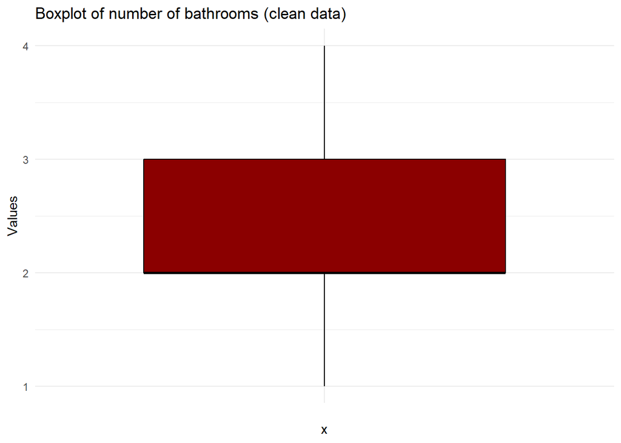

```r
clean_housing_data <- remove_outliers(clean_housing_data, "bath")

ggplot(clean_housing_data, aes(x = "", y = bath)) +
  geom_boxplot(fill = "darkred", color = "black") +
  labs(title = "Boxplot of number of bathrooms (clean data)", y = "Values") +
  theme_minimal()
```

```r
dim(clean_housing_data)
```

```
[1] 20498    16
```

**Interpreation:** This new box plot for bath, shows how the outliers was removed. #### Acre_lot

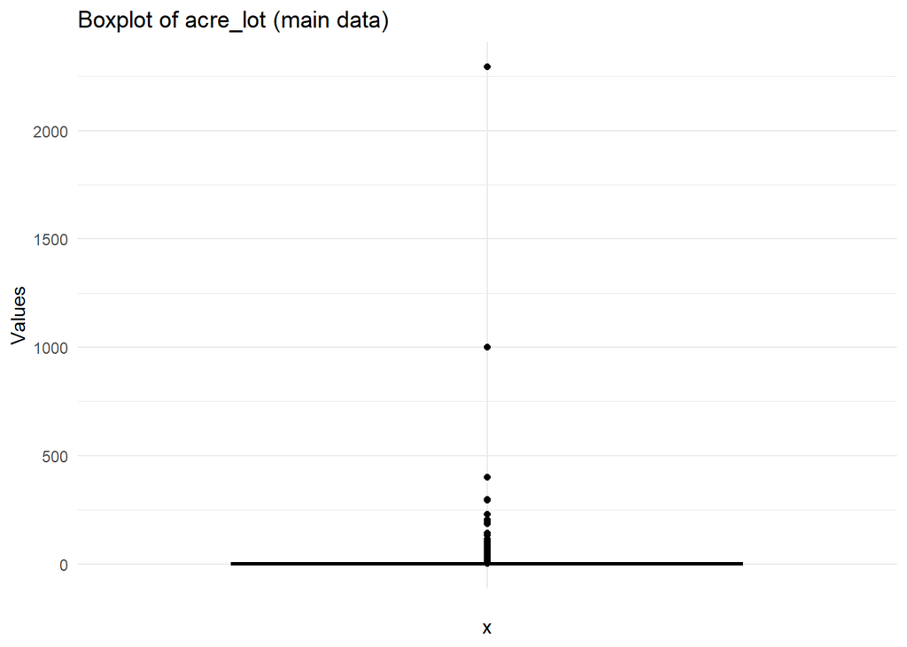

```r
ggplot(clean_housing_data, aes(x = "", y = acre_lot)) +
  geom_boxplot(fill = "darkgreen", color = "black") +
  labs(title = "Boxplot of acre_lot (main data)", y = "Values") +
  theme_minimal()
```

**Interpreation:** This boxplot for acre lot shows some significant outliers.

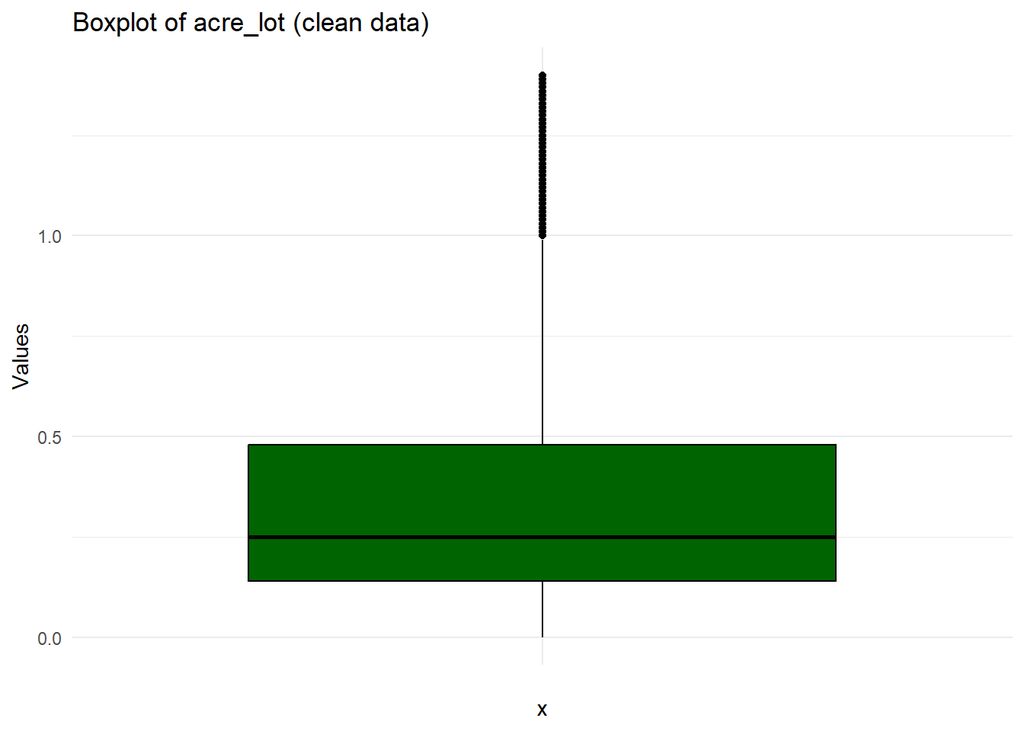

```r
clean_housing_data <- remove_outliers(clean_housing_data, "acre_lot")

ggplot(clean_housing_data, aes(x = "", y = acre_lot)) +
  geom_boxplot(fill = "darkgreen", color = "black") +
  labs(title = "Boxplot of acre_lot (clean data)", y = "Values") +
  theme_minimal()
```

```r
dim(clean_housing_data)
```

```
[1] 18495    16
```

**Interpreation:** This new boxplot for acre lot, show a better distribution of the values for this variable.

#### House size

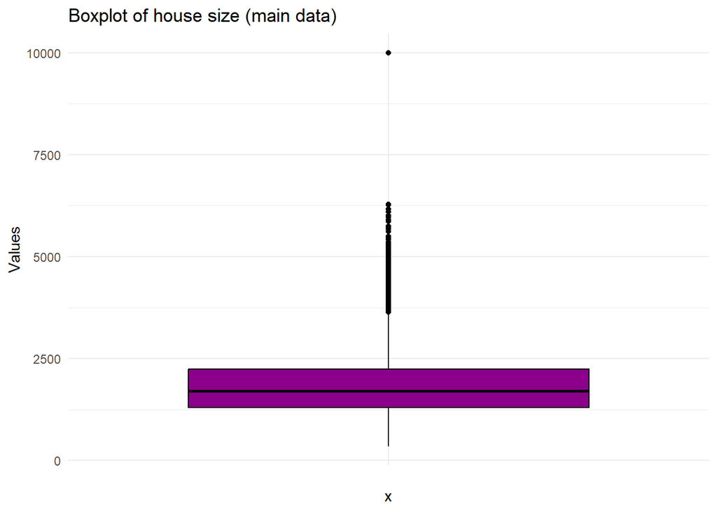

```r
ggplot(clean_housing_data, aes(x = "", y = house_size)) +
  geom_boxplot(fill = "magenta4", color = "black") +
  labs(title = "Boxplot of house size (main data)", y = "Values") +
  theme_minimal()
```

**Interpreation:** This box plot for the variable house size show some outliers out ob the box.

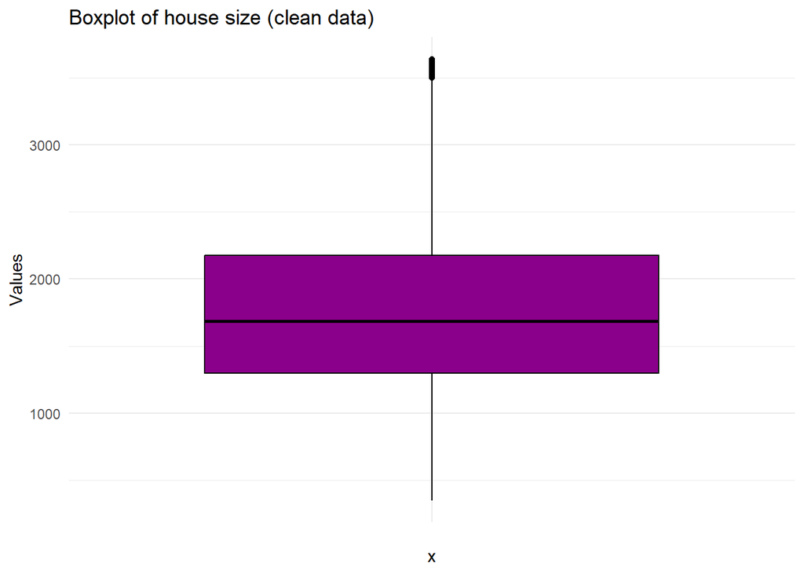

```r
clean_housing_data <- remove_outliers(clean_housing_data, "house_size")

ggplot(clean_housing_data, aes(x = "", y = house_size)) +
  geom_boxplot(fill = "magenta4", color = "black") +
  labs(title = "Boxplot of house size (clean data)", y = "Values") +
  theme_minimal()
```

```r
dim(clean_housing_data)
```

```
[1] 17933    16
```

**Interpreation:** After of the process for remove outliers, this box plot shows a better distribution for the variable house size.

#### Household Income

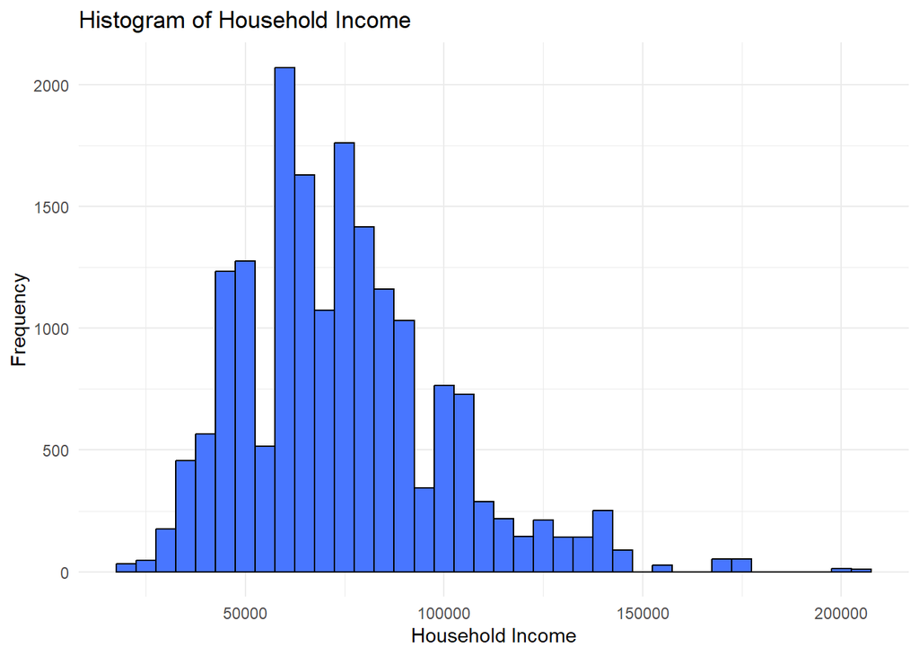

```r
ggplot(clean_housing_data, aes(x = household_income)) +
  geom_histogram(binwidth = 5000, fill = "royalblue1", color = "black") +
  labs(title = "Histogram of Household Income", x = "Household Income", y = "Frequency") +theme_minimal()
```

**Interpreation:** Analyzing the variable household income, this histogram show that the most of the values are between 50k and 100k dollars per year.

#### Density of Population

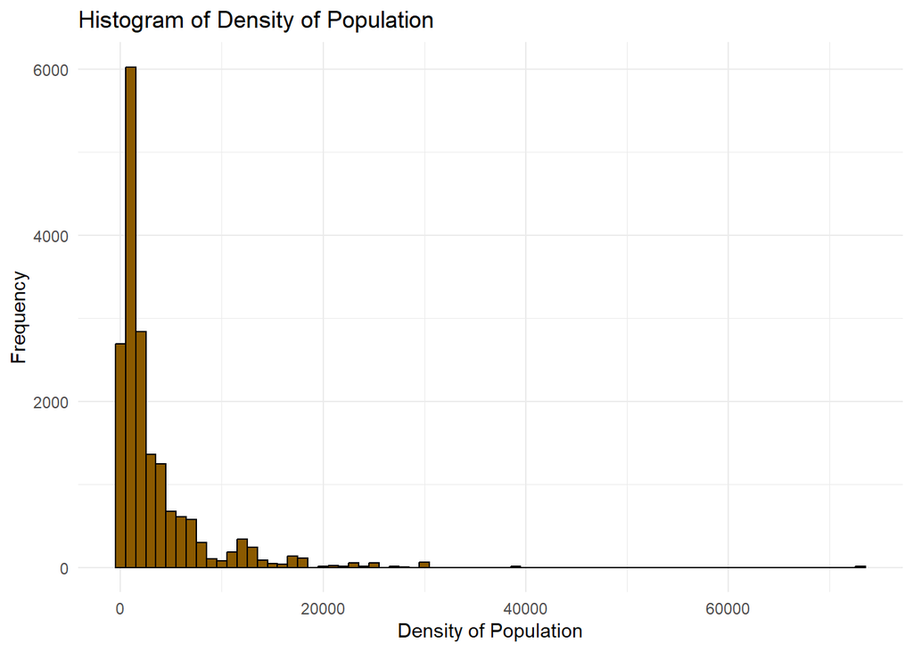

```r
ggplot(clean_housing_data, aes(x = population_density)) +
  geom_histogram(binwidth = 1000, fill = "orange4", color = "black") +
  labs(title = "Histogram of Density of Population", x = "Density of Population", y = "Frequency") +theme_minimal()
```

#### Crime Index

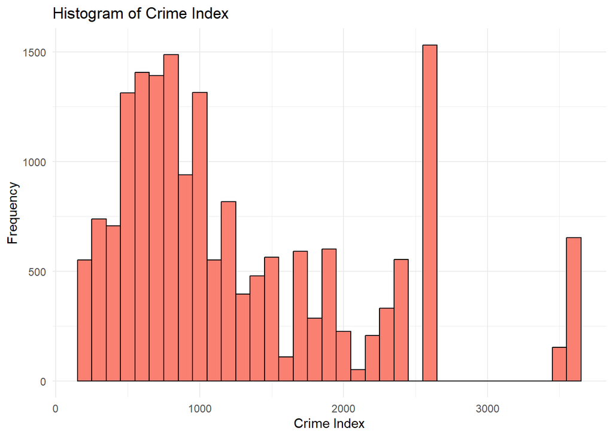

```r
ggplot(clean_housing_data, aes(x = crime_index)) +
  geom_histogram(binwidth = 100, fill = "salmon", color = "black") +
  labs(title = "Histogram of Crime Index", x = "Crime Index", y = "Frequency") +theme_minimal()
```

#### Price

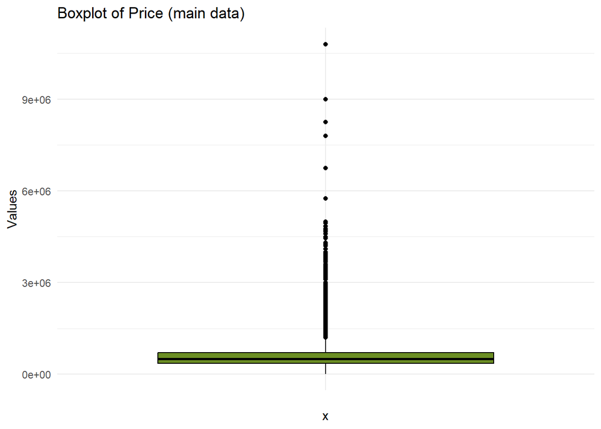

```r
ggplot(clean_housing_data, aes(x = "", y = price)) +
  geom_boxplot(fill = "olivedrab", color = "black") +
  labs(title = "Boxplot of Price (main data)", y = "Values") +
  theme_minimal()
```

**Interpretation:** This box plot for the price variable shows some outliers.

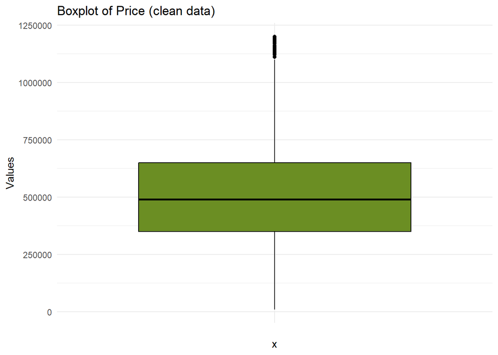

```r
clean_housing_data <- remove_outliers(clean_housing_data, 'price')

ggplot(clean_housing_data, aes(x = "", y = price)) +
  geom_boxplot(fill = "olivedrab", color = "black") +
  labs(title = "Boxplot of Price (clean data)", y = "Values") +
  theme_minimal()
```

```r
dim(clean_housing_data)
```

```
[1] 16916    16
```

**Interpretation:** After of the process of remove outliers, this new boxplot shows a best distribution for the values for the variable price.

#### Correlations

**Hypothesis #1**

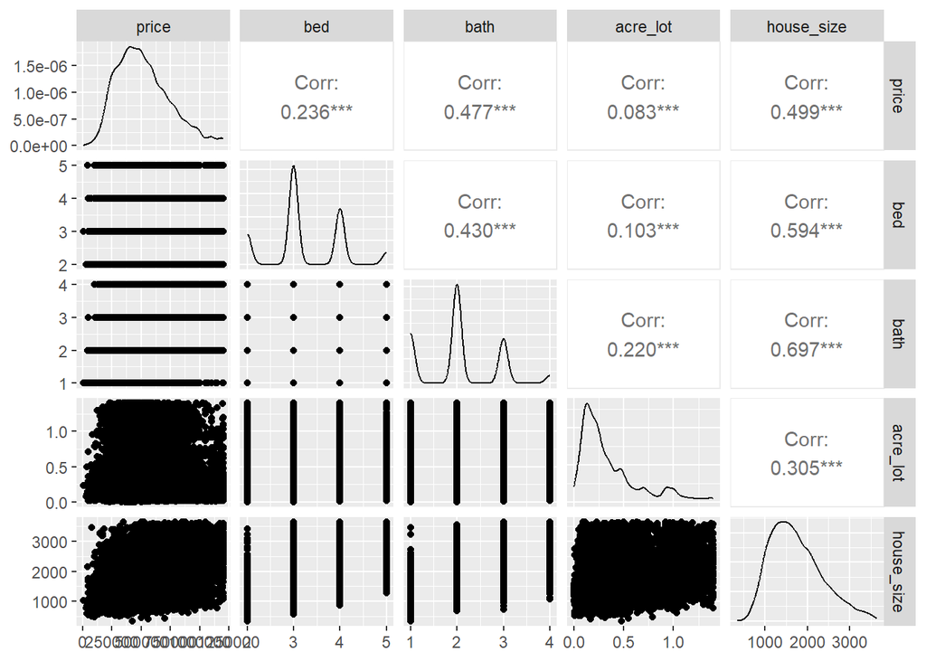

```r
hypo1_corrdata <- select(clean_housing_data, price,bed, bath, acre_lot, house_size)

install.packages("GGally")
library(GGally)
pairs_plot_h1 <- ggpairs(hypo1_corrdata)

pairs_plot_h1
```

**Hypothesis #2**

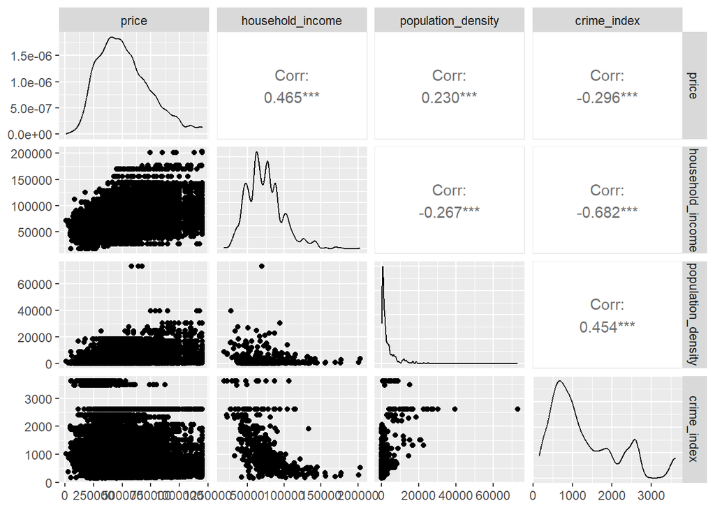

```r
hypo2_corrdata <- select(clean_housing_data, price,household_income, population_density, crime_index)

pairs_plot_h2 <- ggpairs(hypo2_corrdata)

pairs_plot_h2
```

### Hypothesis testing

#### Hypothesis 1

**Hypothesis #1: Larger houses is associated with higher housing prices linked to price perception, utility, prestige and status.**

Sub-hypothesis: **- H1-1: The number of bedrooms positively correlates with higher housing prices.**

```r
model1_h1_1 <- lm(price ~ bed, data = clean_housing_data)

summary(model1_h1_1)
```

```
Call:
lm(formula = price ~ bed, data = clean_housing_data)

Residuals:
    Min      1Q  Median      3Q     Max
-593665 -155284  -27978  128735  764816

Coefficients:
            Estimate Std. Error t value Pr(>|t|)
(Intercept)   299598       7180   41.73   <2e-16 ***
bed            67793       2147   31.57   <2e-16 ***
---
Signif. codes:  0 '***' 0.001 '**' 0.01 '*' 0.05 '.' 0.1 ' ' 1

Residual standard error: 219200 on 16914 degrees of freedom
Multiple R-squared:  0.05565,   Adjusted R-squared:  0.05559
F-statistic: 996.7 on 1 and 16914 DF,  p-value: < 2.2e-16
```

**Interpretation:** The model equation is: price = 299598 + 67793 × bed

For each additional bedroom, the estimated price increases by $67,793.00. This model suggests that the number of bedrooms has a statistically significant effect on the price of houses.

Conclusion: This **supports** the sub-hypothesis that the number of bedrooms is positively correlated with higher housing prices.

**- H1-2: The number of bathrooms is positively associated with increased housing prices.**

```r
model2_h1_2 <- lm(price ~ bath, data = clean_housing_data)

summary(model2_h1_2)
```

```
Call:
lm(formula = price ~ bath, data = clean_housing_data)

Residuals:
    Min      1Q  Median      3Q     Max
-687549 -137934  -14388  112873  823873

Coefficients:
            Estimate Std. Error t value Pr(>|t|)
(Intercept)   239320       4258   56.21   <2e-16 ***
bath          136807       1938   70.59   <2e-16 ***
---
Signif. codes:  0 '***' 0.001 '**' 0.01 '*' 0.05 '.' 0.1 ' ' 1

Residual standard error: 198300 on 16914 degrees of freedom
Multiple R-squared:  0.2276,    Adjusted R-squared:  0.2275
F-statistic:  4983 on 1 and 16914 DF,  p-value: < 2.2e-16
```

**Interpretation:** The model equation is: price = 239320 + 136807 × bath

For each additional bathrooms, the estimated price increases by $136,807.00. This model suggests that the number of bathrooms has a statistically significant effect on the price of houses.

Conclusion: This **supports** the sub-hypothesis that the number of bathrooms is positively is positively associated with increased housing prices.

**- H1-3: Larger house sizes in square feet are positively linked to higher house prices.**

```r
model3_h1_3 <- lm(price ~ house_size, data = clean_housing_data)

summary(model3_h1_3)
```

```
Call:
lm(formula = price ~ house_size, data = clean_housing_data)

Residuals:
    Min      1Q  Median      3Q     Max
-755338 -134650  -17978  107664  809609

Coefficients:
             Estimate Std. Error t value Pr(>|t|)
(Intercept) 1.986e+05  4.542e+03   43.72   <2e-16 ***
house_size  1.845e+02  2.461e+00   74.98   <2e-16 ***
---
Signif. codes:  0 '***' 0.001 '**' 0.01 '*' 0.05 '.' 0.1 ' ' 1

Residual standard error: 195500 on 16914 degrees of freedom
Multiple R-squared:  0.2495,    Adjusted R-squared:  0.2494
F-statistic:  5623 on 1 and 16914 DF,  p-value: < 2.2e-16
```

**Interpretation:** The model equation is: price = 198600 + 184.50 × sq-feet(house size)

For each additional square foot in house size, the estimated price increases by $184.50. This model suggests that house size has a statistically significant effect on the price of houses.

Conclusion: This **supports** the sub-hypothesis that Larger house sizes in square feet are positively are positively linked to higher house prices..

**- H1-4: Increased lot or property sizes are positively correlated with higher housing prices.**

```r
model4_h1_4 <- lm(price ~ acre_lot, data = clean_housing_data)

summary(model4_h1_4)
```

```
Call:
lm(formula = price ~ acre_lot, data = clean_housing_data)

Residuals:
    Min      1Q  Median      3Q     Max
-502005 -166456  -31202  134812  701048

Coefficients:
            Estimate Std. Error t value Pr(>|t|)
(Intercept)   497709       2680  185.74   <2e-16 ***
acre_lot       62158       5723   10.86   <2e-16 ***
---
Signif. codes:  0 '***' 0.001 '**' 0.01 '*' 0.05 '.' 0.1 ' ' 1

Residual standard error: 224800 on 16914 degrees of freedom
Multiple R-squared:  0.006926,  Adjusted R-squared:  0.006867
F-statistic:   118 on 1 and 16914 DF,  p-value: < 2.2e-16
```

**Interpretation:** The model equation is: price = 497709 + 62158 × acre_lot

For each additional acre in lot size, the estimated price increases by $62,158.00. This model suggests that lot size has a statistically significant effect on the price of houses.

Conclusion: This **supports** the sub-hypothesis that Increased lot or property sizes are positively correlated with higher housing prices.

**Hypothesis #2: The location of the house and its social and economic relationships are significantly correlated with its price.**

Sub-hypothesis: - H2-1: Housing prices are higher in Western MA due to factors such as scenic landscapes, proximity to urban centers, and potentially lower crime rates compared to more urban areas.

```r
clean_housing_data$region <- as.factor(clean_housing_data$region)
clean_housing_data$region <- relevel(clean_housing_data$region, ref = "Western")
model5_h2_1 <- lm(price ~ region, data = clean_housing_data)
summary(model5_h2_1)
```

```
Call:
lm(formula = price ~ region, data = clean_housing_data)

Residuals:
    Min      1Q  Median      3Q     Max
-628300 -122077  -32295   96921  793023

Coefficients:
                Estimate Std. Error t value Pr(>|t|)
(Intercept)       288345       3468   83.15   <2e-16 ***
regionCentral      93632       4968   18.84   <2e-16 ***
regionNortheast   349954       4153   84.27   <2e-16 ***
regionSoutheast   279733       4296   65.12   <2e-16 ***
---
Signif. codes:  0 '***' 0.001 '**' 0.01 '*' 0.05 '.' 0.1 ' ' 1

Residual standard error: 182300 on 16912 degrees of freedom
Multiple R-squared:  0.3475,    Adjusted R-squared:  0.3474
F-statistic:  3002 on 3 and 16912 DF,  p-value: < 2.2e-16
```

**Interpretation:**

The model equation is: price = 288345 + 93632×regionCentral + 349954×regionNortheast + 279733×regionSoutheast

Compared to the baseline Western region, the estimated price increases by $93,632.00 for houses in the Central region, by $349,954.00 for houses in the Northeast region, and by $279,733.00 for houses in the Southeast region. This model suggests that region has a statistically significant effect on the price of houses.

Conclusion: Housing prices vary significantly across different regions. In particular, prices tend to be higher in the Central, Northeast, and Southeast regions compared to the baseline Western region. This model explain an evidence for **reject** the sub hypothesis #1 for the hypothesis #2, the house price doesn’t increase directly in Western, Massachusetts, but this model just can predict a 34.75% of the houses prices in the dataset.

- H2-2: Regions with higher average household incomes will have higher housing prices because individuals with higher incomes can afford more expensive housing based in status, prestige, amenities and comfort.

```r
model6_h2_2 <- lm(price ~ household_income, data = clean_housing_data)

summary(model6_h2_2)
```

```
Call:
lm(formula = price ~ household_income, data = clean_housing_data)

Residuals:
    Min      1Q  Median      3Q     Max
-597248 -141883  -34866  112867  850727

Coefficients:
                  Estimate Std. Error t value Pr(>|t|)
(Intercept)      2.075e+05  4.824e+03   43.03   <2e-16 ***
household_income 4.252e+00  6.223e-02   68.32   <2e-16 ***
---
Signif. codes:  0 '***' 0.001 '**' 0.01 '*' 0.05 '.' 0.1 ' ' 1

Residual standard error: 199700 on 16914 degrees of freedom
Multiple R-squared:  0.2163,    Adjusted R-squared:  0.2162
F-statistic:  4668 on 1 and 16914 DF,  p-value: < 2.2e-16
```

**Interpretation:**

The model equation is: price = 207500 + 4.25 x household_income

For each additional $ that increase in household income, the estimated price increases by $4.25. This model suggests that household income has a statistically significant effect on the price of houses.

Conclusion: Regions with higher average household incomes tend to have higher housing prices. This **supports** the sub-hypothesis that regions with higher average household incomes will have higher housing prices because individuals with higher incomes can afford more expensive housing based on factors such as status, prestige, amenities, and comfort.

- H2-3: Areas with higher population densities will experience higher housing prices because they offer locations with access to amenities, employment opportunities, cultural attractions, and more.

```r
model7_h2_3 <- lm(price ~ population_density, data = clean_housing_data)

summary(model7_h2_3)
```

```
Call:
lm(formula = price ~ population_density, data = clean_housing_data)

Residuals:
    Min      1Q  Median      3Q     Max
-836021 -161482  -28607  130736  715602

Coefficients:
                    Estimate Std. Error t value Pr(>|t|)
(Intercept)        4.812e+05  2.108e+03  228.33   <2e-16 ***
population_density 1.278e+01  4.164e-01   30.68   <2e-16 ***
---
Signif. codes:  0 '***' 0.001 '**' 0.01 '*' 0.05 '.' 0.1 ' ' 1

Residual standard error: 219600 on 16914 degrees of freedom
Multiple R-squared:  0.05272,   Adjusted R-squared:  0.05266
F-statistic: 941.3 on 1 and 16914 DF,  p-value: < 2.2e-16
```

**Interpretation:**

The model equation is:

price = 481200 + 12.78 x population_density

For each additional unit increase in population density, the estimated price increases by $12.78. This model suggests that population density has a statistically significant effect on the price of houses.

Conclusion: This **supports** the sub-hypothesis that Areas with higher population densities will experience higher housing prices because they offer locations with access to amenities, employment opportunities, cultural attractions, and more.

- H2-4: Areas with higher crime rates are positively correlated with lower housing prices due to perceptions of insecurity, increased insurance premiums, and the need for costly security measures.

```r
model8_h2_4 <- lm(price ~ crime_index, data = clean_housing_data)

summary(model8_h2_4)
```

```
Call:
lm(formula = price ~ crime_index, data = clean_housing_data)

Residuals:
    Min      1Q  Median      3Q     Max
-560447 -150518  -37717  123480  783302

Coefficients:
              Estimate Std. Error t value Pr(>|t|)
(Intercept) 619133.535   2968.062  208.60   <2e-16 ***
crime_index    -77.591      1.926  -40.28   <2e-16 ***
---
Signif. codes:  0 '***' 0.001 '**' 0.01 '*' 0.05 '.' 0.1 ' ' 1

Residual standard error: 215500 on 16914 degrees of freedom
Multiple R-squared:  0.08753,   Adjusted R-squared:  0.08747
F-statistic:  1622 on 1 and 16914 DF,  p-value: < 2.2e-16
```

**Interpretation:**

The model equation is: *price = 619134 - 77.59 x crime_index*

For each unit increase in the crime index, the estimated price decreases by $77.59. This model suggests that the crime index has a statistically significant effect on the price of houses.

Conclusion: This **supports** the sub-hypothesis that Areas with higher crime rates are positively correlated with lower housing prices due to perceptions of insecurity, increased insurance premiums, and the need for costly security measures.

#### Final model

```r
model9_final <- lm(price ~ house_size + bed + bath + region + population_density + household_income + crime_index, data = clean_housing_data)

summary(model9_final)
```

```
Call:
lm(formula = price ~ house_size + bed + bath + region + population_density +
    household_income + crime_index, data = clean_housing_data)

Residuals:
    Min      1Q  Median      3Q     Max
-987057  -78908   -9733   62112  781223

Coefficients:
                     Estimate Std. Error t value Pr(>|t|)
(Intercept)        -1.227e+05  7.543e+03 -16.264  < 2e-16 ***
house_size          1.116e+02  2.659e+00  41.947  < 2e-16 ***
bed                -9.635e+03  1.621e+03  -5.942 2.86e-09 ***
bath                6.160e+04  1.801e+03  34.200  < 2e-16 ***
regionCentral       2.833e+04  3.693e+03   7.672 1.79e-14 ***
regionNortheast     1.798e+05  3.733e+03  48.159  < 2e-16 ***
regionSoutheast     1.822e+05  3.385e+03  53.826  < 2e-16 ***
population_density  1.625e+01  3.412e-01  47.633  < 2e-16 ***
household_income    2.626e+00  5.932e-02  44.261  < 2e-16 ***
crime_index        -1.293e+01  1.799e+00  -7.188 6.86e-13 ***
---
Signif. codes:  0 '***' 0.001 '**' 0.01 '*' 0.05 '.' 0.1 ' ' 1

Residual standard error: 131900 on 16906 degrees of freedom
Multiple R-squared:  0.6585,    Adjusted R-squared:  0.6584
F-statistic:  3623 on 9 and 16906 DF,  p-value: < 2.2e-16
```

**Interpretation:**

**Coefficients:**

- House Size (house_size): For every unit **increase** in house size, the price is estimated to increase by $111.60.
- Bedrooms (bed): Each additional bedroom **decreases** the price by $9,635.
- Bathrooms (bath): Each additional bathroom **increases** the price by $61,600.
- Region (region): Compared to a reference region (Western), the Central region tends to have prices $28,330 higher, the Northeast region tends to have prices $179,800 higher, and the Southeast region tends to have prices $182,200 higher.
- Population Density (population_density): For every one-unit increase in population density, the price **increases** by $16.25.
- Household Income (household_income): For every one-unit increase in household income, the price increases by $2.63.
- Crime Index (crime_index): For every one-unit increase in the crime index, the price **decreases** by $12.93.

**Significance:** In this model, all variables have highly significant effects on price.

**R-squared:** The R-squared value (0.6585) indicates that approximately 65.85% of the variability in house prices can be explained by this model.

**Conclusion:** Overall, this model suggests that house size, bedrooms, bathrooms, region, population density, household income, and crime index are significant predictors of house prices.

### Model Comparisons

```r
options(repos = c(CRAN = "https://cloud.r-project.org"))
install.packages("broom")
library(broom)

Model_names <- c("model1_h1_1","model2_h1_2","model3_h1_3","model4_h1_4","model5_h2_1", "model6_h2_2", "model7_h2_3","model8_h2_4","model9_final")

`BIC` <- c(glance(model1_h1_1)$BIC,glance(model2_h1_2)$BIC,
            glance(model3_h1_3)$BIC,glance(model4_h1_4)$BIC,glance(model5_h2_1)$BIC, glance(model6_h2_2)$BIC, glance(model7_h2_3)$BIC, glance(model8_h2_4)$BIC, glance(model9_final)$BIC)

`AIC` <- c(glance(model1_h1_1)$AIC,glance(model2_h1_2)$AIC,
            glance(model3_h1_3)$AIC,glance(model4_h1_4)$AIC,glance(model5_h2_1)$AIC, glance(model6_h2_2)$AIC, glance(model7_h2_3)$AIC, glance(model8_h2_4)$AIC, glance(model9_final)$AIC)

`Adjusted R-square` <- c(glance(model1_h1_1)$adj.r.squared,glance(model2_h1_2)$adj.r.squared,
            glance(model3_h1_3)$adj.r.squared,glance(model4_h1_4)$adj.r.squared,glance(model5_h2_1)$adj.r.squared, glance(model6_h2_2)$adj.r.squared, glance(model7_h2_3)$adj.r.squared, glance(model8_h2_4)$adj.r.squared, glance(model9_final)$adj.r.squared)

num_observations <- c(nobs(model1_h1_1), nobs(model2_h1_2), nobs(model3_h1_3),
                      nobs(model4_h1_4), nobs(model5_h2_1), nobs(model6_h2_2),
                      nobs(model7_h2_3), nobs(model8_h2_4), nobs(model9_final))

models_summary <- data.frame(Model_names, num_observations, `AIC`, `BIC`, `Adjusted R-square`)

models_summary
```

| Model_names | num_observations | AIC | BIC | Adjusted.R.square |
| --- | --- | --- | --- | --- |
| model1_h1_1 | 16916 | 464073.8 | 464097.0 | 0.05559138 |
| model2_h1_2 | 16916 | 460674.2 | 460697.4 | 0.22753194 |
| model3_h1_3 | 16916 | 460187.5 | 460210.7 | 0.24944023 |
| model4_h1_4 | 16916 | 464924.8 | 464948.0 | 0.00686697 |
| model5_h2_1 | 16916 | 457823.8 | 457862.5 | 0.34739566 |
| model6_h2_2 | 16916 | 460919.7 | 460942.9 | 0.21624098 |
| model7_h2_3 | 16916 | 464126.2 | 464149.4 | 0.05266294 |
| model8_h2_4 | 16916 | 463492.8 | 463516.1 | 0.08747417 |
| model9_final | 16916 | 446881.6 | 446966.7 | 0.65835987 |

**Interpretation:** When evaluating the models, I considered several key metrics: Akaike Information Criterion (AIC), Bayesian Information Criterion (BIC), and Adjusted R-Square.

AIC and BIC: Lower values indicate a better model fit. Model9_final has the lowest AIC (446,881.6) and BIC (446,966.7) among all the models. This suggests that model9_final fits the data well with appropriate complexity.

Adjusted R-Square: Higher values indicate a better fit of the model to the data while adjusting for the number of predictors. Model9_final has the highest Adjusted R-Square (0.65835987), indicating it explains the highest proportion of variance in the dependent variable compared to other models.

### Diagnostics

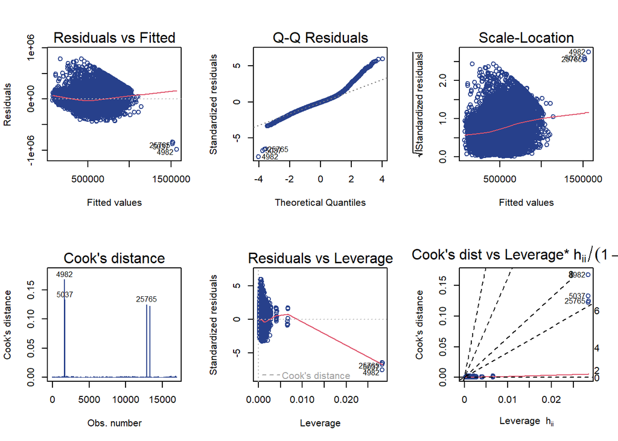

```r
par(mfrow = c(2,3))

plot(model9_final, which = 1:6, col = "royalblue4")
```

```r
install.packages("stargazer")
library(stargazer)
stargazer(model9_final, type = 'text')
```

```
================================================
                        Dependent variable:
                    ----------------------------
                               price
------------------------------------------------
house_size                   111.551***
                              (2.659)

bed                        -9,635.435***
                            (1,621.481)

bath                       61,604.520***
                            (1,801.311)

regionCentral              28,333.860***
                            (3,693.207)

regionNortheast            179,761.500***
                            (3,732.702)

regionSoutheast            182,213.400***
                            (3,385.241)

population_density           16.254***
                              (0.341)

household_income              2.626***
                              (0.059)

crime_index                  -12.930***
                              (1.799)

Constant                  -122,680.700***
                            (7,543.246)

------------------------------------------------
Observations                   16,916
R2                             0.659
Adjusted R2                    0.658
Residual Std. Error   131,867.100 (df = 16906)
F Statistic         3,622.796*** (df = 9; 16906)
================================================
Note:                *p<0.1; **p<0.05; ***p<0.01
```

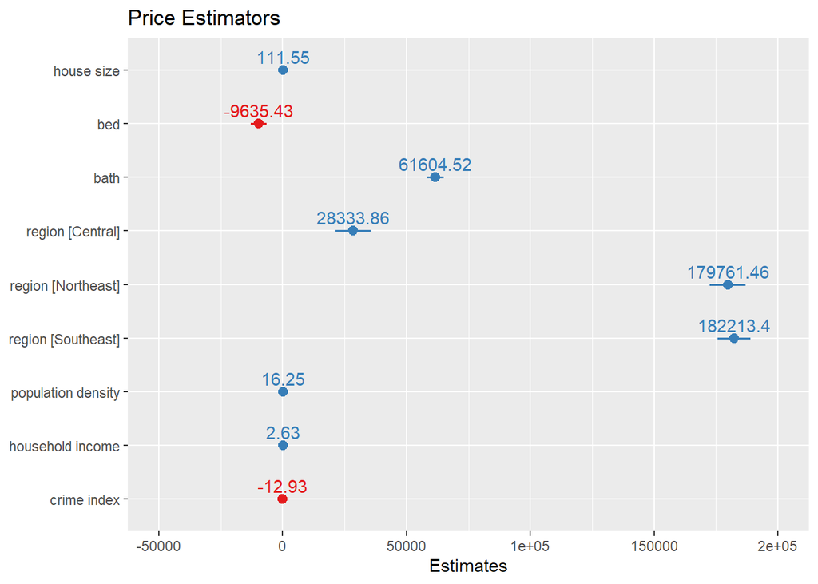

```r
install.packages("sjPlot")
library(sjPlot)
library(ggplot2)

final_plot <- plot_model(model9_final, show.values = FALSE) +
  ggtitle("Price Estimators ")

# Modify the plot to adjust the position of the coefficient labels
final_plot <- final_plot + geom_text(aes(label = paste0(round(estimate, 2), "")), vjust = -0.5)

# Display the modified plot
final_plot
```

```r
ggsave("stimators_plot.jpg", plot = final_plot, dpi = 300)
```

**Region and Price**

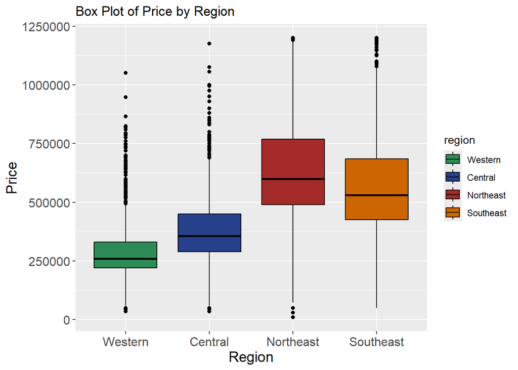

```r
region_plot <- ggplot(clean_housing_data, aes(x = region, y = price, fill = region)) +
  geom_boxplot(color = "black") +
  labs(title = "Box Plot of Price by Region",
       x = "Region",
       y = "Price") +
  scale_fill_manual(values = c("Western" = "seagreen", "Central" = "royalblue4", "Northeast" = "brown", "Southeast" = "darkorange3")) +
  theme(axis.text = element_text(size = 12),
        axis.title = element_text(size = 14))

#ggsave("region_plot.jpg", plot = region_plot, dpi = 300)

region_plot
```

**Interpretation:** This box plot is so interesting, because show the significant influence of the region in price, Northeast with the higher mean in housing prices houses and Western with the lower.

### CONCLUSION

**Key Factors:** - House size, bedrooms, bathrooms, region, population density, household income, and crime index are significant predictors of house prices.

**Impact on Price:** - House size: Each unit increase raises the price by $111.60. - Bedrooms: Each additional bedroom decreases the price by $9,635. - Bathrooms: Each additional bathroom increases the price by $61,600. - Region: Central, Northeast, and Southeast regions have significantly higher prices compared to the Western region. - Population Density: Price increases by $16.25 for every unit increase in population density. - Household Income: Price increases by $2.63 for every unit increase in household income. - Crime Index: Price decreases by $12.93 for every unit increase in the crime index.

**Significance:** All variables have highly significant effects on price.

**Model Performance:** The model explains approximately 65.85% of the variability in house prices (R-squared = 0.6585).

The analysis shows a comprehensive understanding of the factors influencing housing prices. The model indicates that several key variables significantly impact housing prices. Notably, larger house sizes, increased bathroom numbers, and higher population densities correlate with higher prices, while additional bedrooms and a higher crime index lead to price decreases. However, regional differences play a relevant role, with the Central, Northeast, and Southeast regions exhibiting notably higher prices compared to the reference region (Western). Household income also is as a significant predictor affecting housing prices. These findings show how diverse factors impact the housing markets, from property characteristics to socioeconomic indicators. The model’s strong explanatory power, as reflected by its high R-squared value, underscores its utility in understanding and predicting housing price variations in Massachusetts.